# Data Visualizations

2018-01-25

Using R in Life Sciences - January 2018

## A random example

Let's look a sophisticated R plot example first before doing anything else: The code will reproduce the circos plot in the intro presentation. Do you recognize the plot?

```r
source(paste0(root, "/code/circos_example.R"))
```

[output not shown]

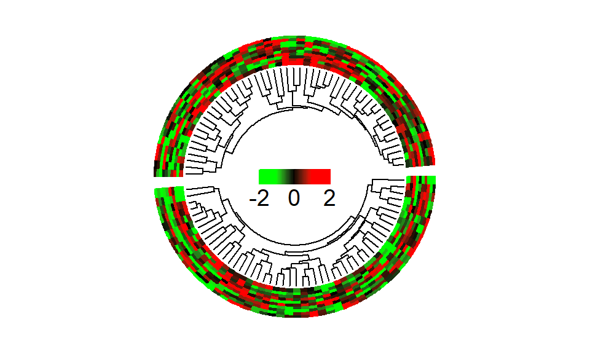

## Learning materials:

Chapter 1: "R for Data Science" by Wickham and Grolemund http://r4ds.had.co.nz/

[figure not shown]

## Learning aims

- Visualise your data using ggplot2.
- R has several systems for making graphs
- ggplot2 is one of the most elegant and most versatile.
- ggplot2 implements the **grammar of graphics**, a coherent system for describing and building graphs.
- With ggplot2, you can do more faster by learning one system and applying it in many places.
- During the demos we will see examples of R's other plotting systems {lattice} and {base} plotting and Bioconductor packages)

additonal reading: "The Layered Grammar of Graphics", http://vita.had.co.nz/papers/layered-grammar.pdf.

## Packages

```r
library(tidyverse)
```

## Installing "tidyverse" manually

*If you run the previous code and get the error message "there is no package called ‘tidyverse’", you'll need to first install it, then run `library()` once again.*

```r
## install.packages("tidyverse")
library(tidyverse)
```

## Running a plot (ggplot2)

```r
# create 100 random normals with mean = 10 and sd = 2
set.seed(seed = 12345)
normal <- rnorm(100, mean = 10, sd = 2)
normal <- as_tibble(normal)

# create histogram of object "normal"
library(ggplot2)
g <-ggplot(normal, aes(x=normal))
# Histogram with density instead of counts on y-axis
plot <- g +
    geom_histogram(aes(y=..density..),
                   binwidth = 1,
                   colour = "black", fill = "white") +
    geom_density(alpha = .2, fill = "#FF6666") + xlab("value")
# Overlay with transparent density plot
```

## Histograms and normal distributions

- See what happens if you increase the number of datapoints from 100 to 100000 in the function `normal <- rnorm(1000, ...)`. What happens to the plot?
- What does changing the `sd` argument do?
- What does changing the `binwidth = 1` parameter in the call for the plot do? Try setting it to a higher or lower number
- Can you guess what `set.seed` does?

## The histogram plot of the code above

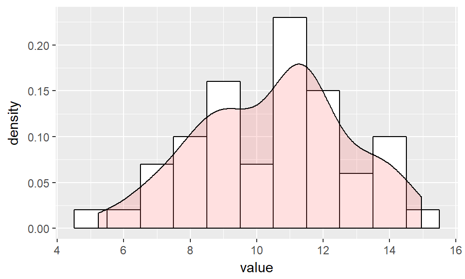

```r
plot
```

## Other distributions - examples

There are other distributions than the normal distribution.

```r
distributions <- data.frame(std.normal=rnorm(10000, m=0, sd=1),
                     wide.normal=rnorm(10000, m=0, sd=2),
                     exponent=rexp(10000, rate=2),
                     uniform=runif(10000, min=-3, max=3)
                     )
distributions <- as_tibble(distributions)
distributions
```

```
## # A tibble: 10,000 x 4
##    std.normal wide.normal exponent uniform
##         <dbl>       <dbl>    <dbl>   <dbl>
##  1      0.224      1.26     1.06   -2.27
##  2     -1.16       0.220    0.747  -0.515
##  3      0.422      2.54     0.0766  2.26
##  4     -1.32      -0.491    0.316   0.807
##  5      0.141      0.0398   1.00    0.0741
##  6     -0.536     -2.38     0.0323 -0.962
##  7     -0.312     -1.78     0.865  -0.459
##  8      1.56      -3.04     0.398   0.878
##  9     -0.448      2.07     0.0265  2.31
## 10      0.321      2.48     0.246  -2.06
## # ... with 9,990 more rows
```

## Plotting distributions

The plots depict two additional distributions. Can you think of one or two other distrubutions, not included?

```r
# Exponential decay distribution plot
plot_exp <- ggplot(distributions, aes(x= exponent)) +
  geom_histogram(aes(y=..density..),
                   binwidth=0.1,
                   colour="black", fill="white") +
    geom_density(alpha=.2, fill="blue") + xlab("value")

# Uniform distribution density plot
plot_uniform <- ggplot(distributions, aes(x= uniform)) +
  geom_histogram(aes(y=..density..),
                   binwidth=0.1,
                   colour="black", fill="white") +
    geom_density(alpha=.2, fill="green") + xlab("value")
```

## Panel with both plots

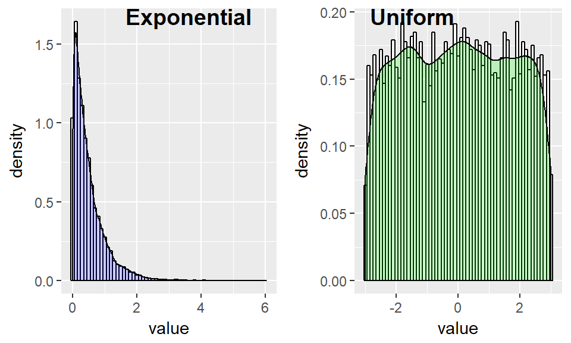

```r
cowplot::plot_grid(plot_exp, plot_uniform,
                   labels = c("Exponential", "Uniform"), hjust = -1)
```

## Bimodal distributions

We will look at this distribution using one of R's build-in datasets: the eruptions of the Yellowstone Geyser "Old Faithful". Information on the dataset can be found running the command `?faithful` in the console.

## The `faithful` dataset

```r
library(mixtools)
data(faithful)
faithful <- as_tibble(faithful)
faithful
```

```
## # A tibble: 272 x 2
##    eruptions waiting
##  *     <dbl>   <dbl>
##  1      3.60    79.0
##  2      1.80    54.0
##  3      3.33    74.0
##  4      2.28    62.0
##  5      4.53    85.0
##  6      2.88    55.0
##  7      4.70    88.0
##  8      3.60    85.0
##  9      1.95    51.0
## 10      4.35    85.0
## # ... with 262 more rows
```

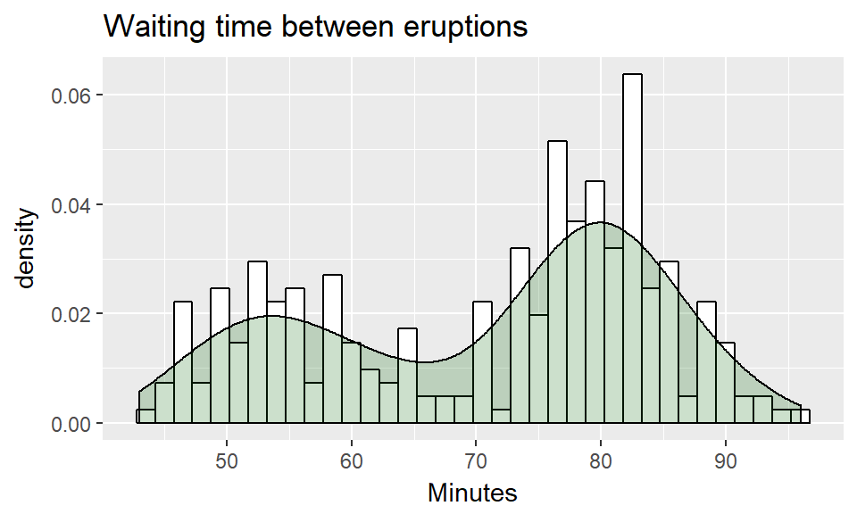

```r
plot_faithful <- ggplot(faithful, aes(x= waiting)) +
    geom_histogram(aes(y=..density..),
                   binwidth=1.5,
                   colour="black", fill="white") +
    geom_density(alpha=.2, fill="darkgreen") + xlab("Minutes") +
  ggtitle("Waiting time between eruptions")
plot_faithful
```

## Drawing conclusions from a density distribution

- Which conclusions can you derive from this plot about the geyser's waiting time?
- How long would you wait at the Geyser?

## Shiny apps

- Shiny is an open source application
- Powerfully illustrate the use of R to generate visualizations.

There are many, many examples on nice shiny apps that can illustrate e.g. complex mathematical or statistical models.

See http://shiny.rstudio.com/

See e.g. the example on different chemical educational shiny apps:

http://dpuadweb.depauw.edu/harvey_web/shiny.html

## Visual respresentations with ggplot2 (chapter 1: r4ds)

*The text below was partly reproduced and adapted from "R for Data Science" by Garrett Grolemund and Hadley Wickam, 2016*

To view the book: http://r4ds.had.co.nz/

Type `?ggplot` to get more help and links

## Build in datasets in R

For this exercise we will use the "mpg" ("Miles per gallon") dataset, available in R.

To get info on the dataset: `?mpg`

## The `mpg` dataset

```r
library(tidyverse)
mpg
```

```
## # A tibble: 234 x 11
##    manufacturer model    displ  year   cyl trans   drv     cty   hwy fl
##    <chr>        <chr>    <dbl> <int> <int> <chr>   <chr> <int> <int> <chr>
##  1 audi         a4        1.80  1999     4 auto(l~ f        18    29 p
##  2 audi         a4        1.80  1999     4 manual~ f        21    29 p
##  3 audi         a4        2.00  2008     4 manual~ f        20    31 p
##  4 audi         a4        2.00  2008     4 auto(a~ f        21    30 p
##  5 audi         a4        2.80  1999     6 auto(l~ f        16    26 p
##  6 audi         a4        2.80  1999     6 manual~ f        18    26 p
##  7 audi         a4        3.10  2008     6 auto(a~ f        18    27 p
##  8 audi         a4 quat~  1.80  1999     4 manual~ 4        18    26 p
##  9 audi         a4 quat~  1.80  1999     4 auto(l~ 4        16    25 p
## 10 audi         a4 quat~  2.00  2008     4 manual~ 4        20    28 p
## # ... with 224 more rows, and 1 more variable: class <chr>
```

## Fuel consumption vs engine size

*Do cars with big engines use more fuel than cars with small engines?*

- What does the relationship between engine size and fuel efficiency look like?
- Is it positive?
- Negative?
- Linear?
- Nonlinear?

## `mpg` variables

Among the variables in `mpg` are:

1. `displ`, a car's engine size (*displacement*), in litres.
2. `hwy`, a car's fuel efficiency on the highway, in miles per gallon (mpg).

A car with a low fuel efficiency consumes more fuel than a car with a high fuel efficiency when they travel the same distance.

## Creating a ggplot

To plot `mpg`, run this code to put `displ` on the x-axis and `hwy` on the y-axis:

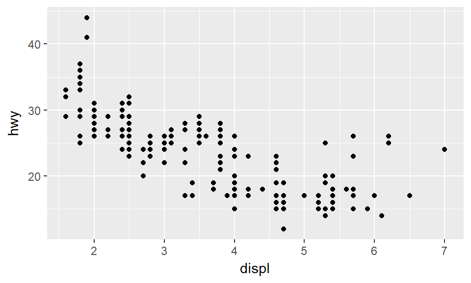

```r
ggplot(data = mpg) +
  geom_point(mapping = aes(x = displ, y = hwy))
```

The plot shows a negative relationship between engine size (`displ`) and fuel efficiency (`hwy`).

## The `ggplot()` function of the ggplot2 package

- Begin a plot with the function `ggplot()`.
- First argument of `ggplot()` is the dataset to use in the graph (`data = ...`).
- Complete your graph by adding one or more layers to `ggplot()`
- Use `+` to add an additional layer
- `geom_point()` adds a layer of points to your plot, which creates a scatterplot
- ggplot2 comes with many geom functions that each add a different type of layer to a plot.

## The `mappig` argument of `aes`

- Each geom function in ggplot2 takes a `mapping` argument.
- Defines how variables in your dataset are mapped to visual properties.
- `mapping` argument is always paired with `aes()`, and the `x` and `y` arguments of `aes()`
- Specify which variables to map to the x and y axes. ggplot2 looks for the mapped variable in the `data` argument, in this case, `mpg`.

## Aesthetic mappings

Can you explain what the red cars represent?

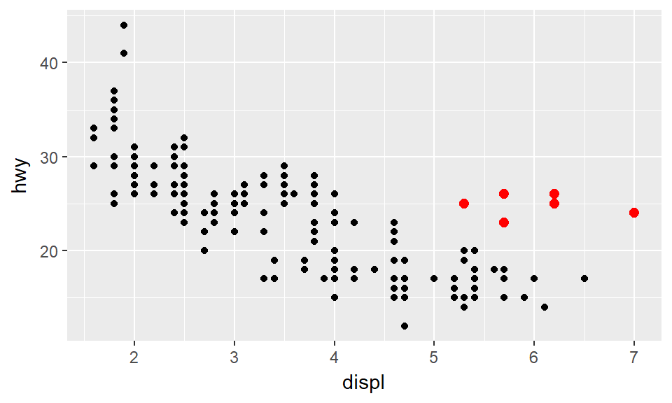

## What are the "red" cars?

- Are they hybrids?
- Look at the `class` value for each car.
- The `class` variable of the `mpg` dataset classifies cars into groups such as compact, midsize, and SUV.
- If the outlying points are hybrids, they should be classified as compact cars or, perhaps, subcompact cars.
- Keep in mind that this data was collected before hybrid trucks and SUVs became popular).

## Showing "group" variables

- Adding a third (grouping) variable, like `class`
- By mapping it to an **aesthetic** (`aes`).
- An aesthetic is a visual property of the objects in your plot.
- Aesthetics include things like the size, the shape, or the color of your points.

## Mapping "group" variables to clour `aesthetics`

- Convey information about your data by mapping the aesthetics in your plot to the variables in your dataset
- Map the colors of your points to the `class` variable to reveal the class of each car.

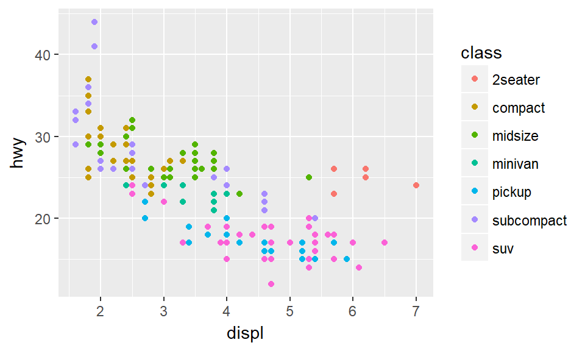

```r
ggplot(data = mpg) +
  geom_point(mapping = aes(x = displ, y = hwy, color = class))
```

## Mapping a different variable to an aesthetic

What happens if we map a different grouping variable to the plot above?

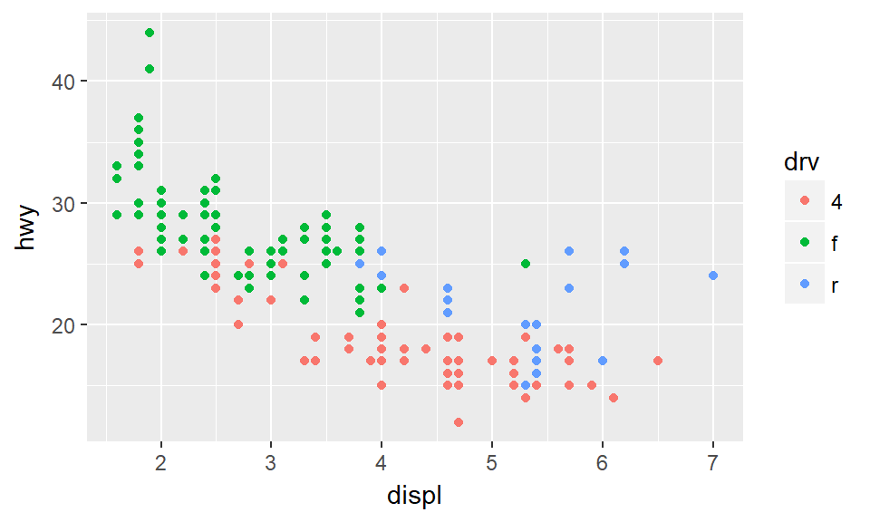

```r
ggplot(data = mpg) +
  geom_point(mapping = aes(x = displ, y = hwy, color = drv))
```

## Mapping colours to grouping variables

- To map an aesthetic to a variable, associate the name of the aesthetic to the name of the variable inside `aes()`.
- Each level of the grouping variable is designated a unique color
- ggplot2 will also add a legend that explains which levels correspond to which values.

## Mapping variables to transperancy `alpha`

- We could have mapped `class` to the *alpha* aesthetic.
- Which controls the transparency of the points.
- Or the shape of the points.

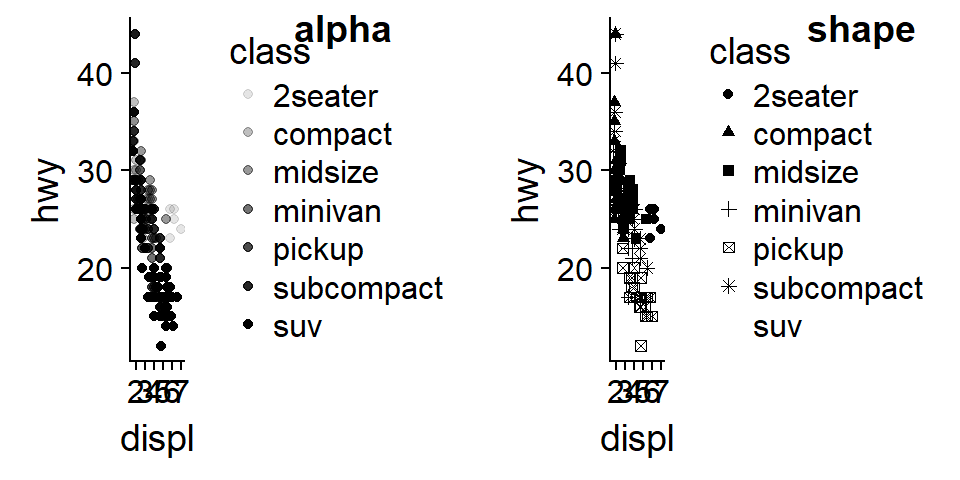

```r
# class as colour shades with setting alpha
alpha <- ggplot(data = mpg) +
  geom_point(mapping = aes(x = displ, y = hwy, alpha = class))
# class as shapes
shape <- ggplot(data = mpg) +
  geom_point(mapping = aes(x = displ, y = hwy, shape = class))
library(cowplot)
cowplot::plot_grid(alpha, shape, labels = c("alpha", "shape"),
                   hjust = -3.0)
```

## Mapping `aes` manually

You can also *set* the aesthetic properties of a `geom()` manually.

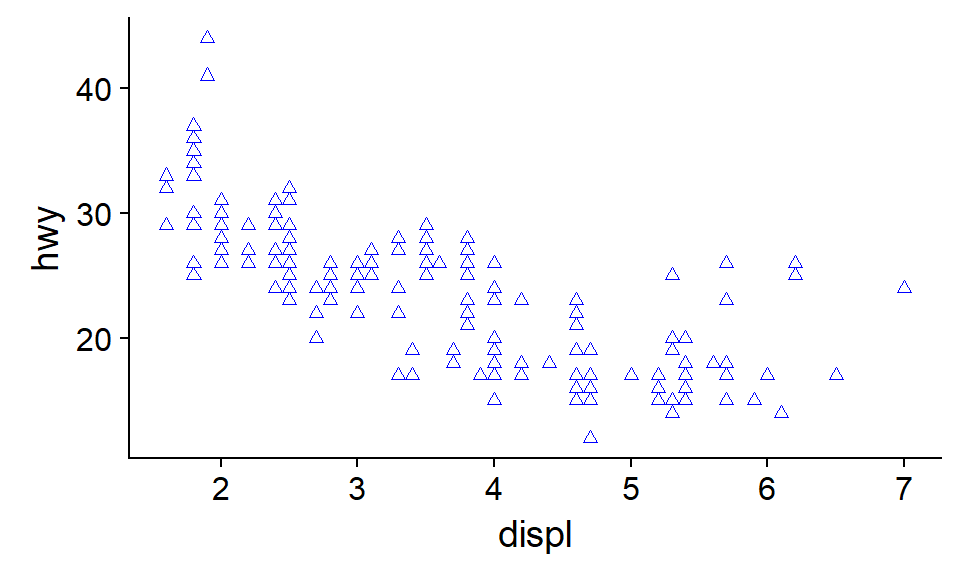

```r
ggplot(data = mpg) +
  geom_point(mapping = aes(x = displ, y = hwy), color = "blue", shape = 24)
```

- The color doesn't convey information about a variable
- Only changes the appearance of the plot.

## Setting values of `aes`

- What happens if you change 24 to 21?
- why are certain blue point darker than others?

You'll need to pick a value that makes sense for that aesthetic:

- The name of a color as a character string.
- The size of a point in mm.
- The shape of a point as a number, as shown in the book (page…)

## Problems writing R code and getting help

Writing R code can be challenging and espacially in the beginning you will get mind-boggling errors. R is extremely picky about capitals and every opening `(` must be matched by a closing `)`. Mind that `.` is the decimal placeholder!

Remember `?function_name` and `?package_name` or `??package_name`, skip down to the examples and look for code that matches what you're trying to do.

Try googling the error message, as it's likely someone else has had the same problem, and has gotten help online.

## Facets with one variable

- Another way to add variables to a plot.
- Particularly useful for categorical variables, is to split your plot into **facets**, subplots that each display one subset of the data.
- Facet your plot by a single variable, use `facet_wrap()`.
- First argument of `facet_wrap()` should be a formula, which you create with `thilda`
- Followed by a variable name
- The variable that you pass to `facet_wrap()` should be discrete.

## A facetted figure of `mpg`

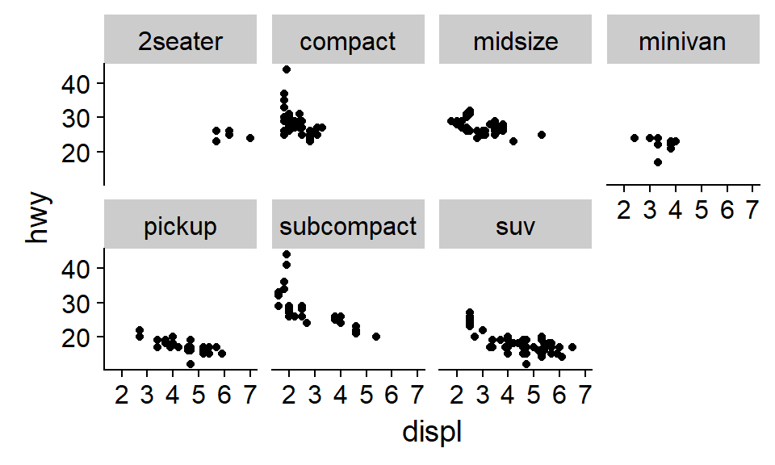

```r
ggplot(data = mpg) +
  geom_point(mapping = aes(x = displ, y = hwy)) +
  facet_wrap(~ class, nrow = 2)
```

## Facets with two variables

To facet your plot on the combination of two variables, add `facet_grid()` to your plot call. The first argument of `facet_grid()` is also a formula. This time the formula should contain two variable names separated by a `thilda`.

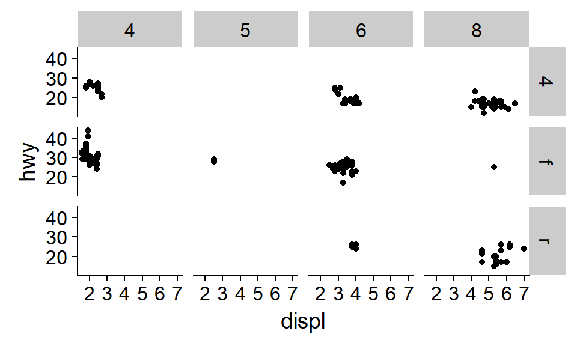

```r
ggplot(data = mpg) +
  geom_point(mapping = aes(x = displ, y = hwy)) +
  facet_grid(drv ~ cyl)
```

## Geometric objects

How are these two plots similar?

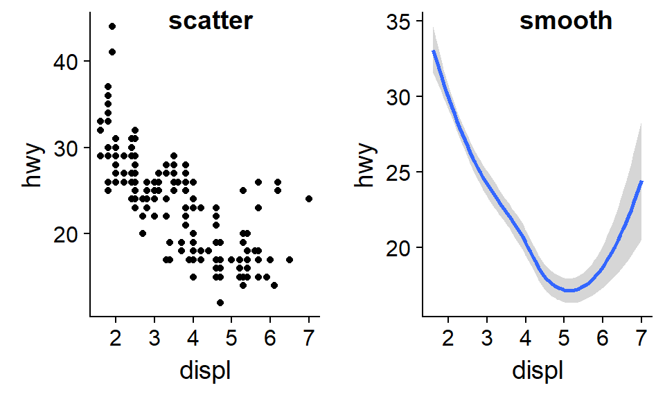

## Grammar of Graphics

Both plots contain the same x variable, the same y variable, and both describe the same data. But the plots are not identical. Each plot uses a different visual object to represent the data. In ggplot2 syntax, we say that they use different **geoms**.

A **geom** is the geometrical object that a plot uses to represent data. People often describe plots by the type of geom that the plot uses. For example, bar charts use bar geoms, line charts use line geoms, boxplots use boxplot geoms, and so on. Scatterplots break the trend; they use the point geom. As we see above, you can use different geoms to plot the same data. The plot on the left uses the point geom, and the plot on the right uses the smooth geom, a smooth line fitted to the data.

## Choose relevant mappings

Every geom function in ggplot2 takes a `mapping` argument. However, not every aesthetic works with every geom. You could set the shape of a point, but you couldn't set the "shape" of a line. On the other hand, you *could* set the linetype of a line. `geom_smooth()` will draw a different line, with a different linetype, for each unique value of the variable that you map to linetype.

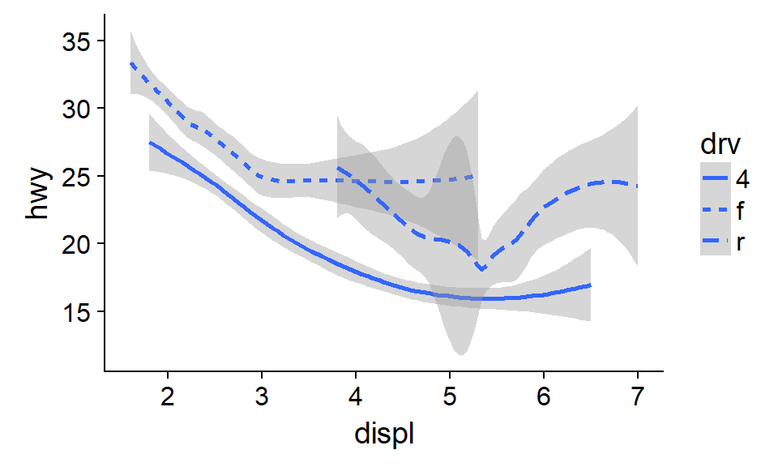

```r
ggplot(data = mpg) +
  geom_smooth(mapping = aes(x = displ, y = hwy, linetype = drv))
```

## Multiple geoms to a grouping variable

Here `geom_smooth()` separates the cars into three lines based on their `drv` value, which describes a car's drivetrain. One line describes all of the points with a `4` value, one line describes all of the points with an `f` value, and one line describes all of the points with an `r` value. Here, `4` stands for four-wheel drive, `f` for front-wheel drive, and `r` for rear-wheel drive.

If this sounds strange, we can make it more clear by overlaying the lines on top of the raw data and then coloring everything according to `drv`.

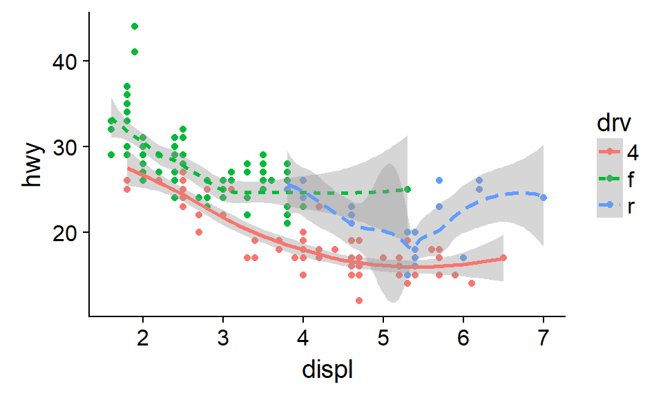

## ggplot2 cheatsheet and extensions

ggplot2 provides over 30 geoms, and extension packages provide even more (see https://www.ggplot2-exts.org for a sampling). The best way to get a comprehensive overview is the ggplot2 cheatsheet, which you can find at http://rstudio.com/cheatsheets. To learn more about any single geom, use help: `?geom_smooth`.

## Adding more geoms

To display multiple geoms in the same plot, add multiple geom functions to `ggplot()`:

```r
ggplot(data = mpg, mapping = aes(x = displ, y = hwy)) +
  geom_point() +
  geom_smooth()

# note the mapping of the aes in ggplot here. We can do individual mapping to the geoms seperately but in this way we save typing and increase readibility of the code.
```

[output not shown]

## Defining local aesthetics

If you place mappings in a geom function, ggplot2 will treat them as local mappings for the layer. It will use these mappings to extend or overwrite the global mappings *for that layer only*. This makes it possible to display different aesthetics in different layers.

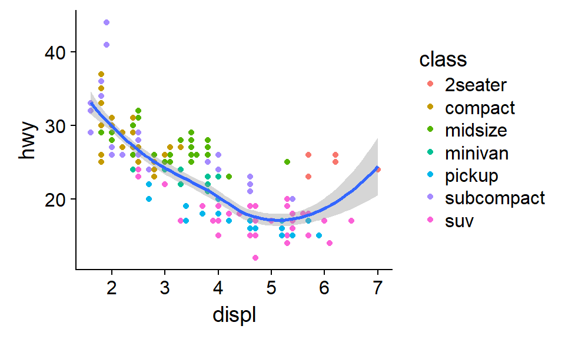

```r
ggplot(data = mpg, mapping = aes(x = displ, y = hwy)) +
  geom_point(mapping = aes(color = class)) +
  geom_smooth()
```

## Mapping different data

You can use the same idea to specify different `data` for each layer. Here, our smooth line displays just a subset of the `mpg` dataset, the subcompact cars. The local data argument in `geom_smooth()` overrides the global data argument in `ggplot()` for that layer only.

## A plot with only "subcompact" cars

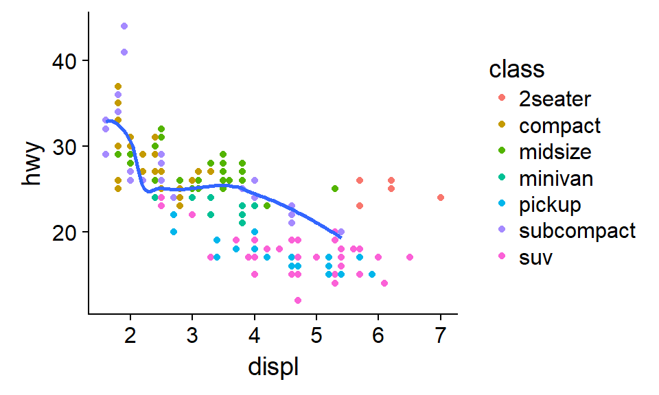

```r
ggplot(data = mpg, mapping = aes(x = displ, y = hwy)) +
  geom_point(mapping = aes(color = class)) +
  geom_smooth(data = filter(mpg, class == "subcompact"), se = FALSE)
```

## The `filter` command

The `filter` command is one of the `verbs` of the `tidyverse` and can be used to select rows in a dataframe.

`select`, `mutate`, `summarize` and `group` are other you wil learn about in the lesson "Introduction to dplyr"

## Bar charts

- Bar charts seem simple, but they are interesting because they reveal something subtle about plots.
- Consider a basic bar chart: `geom_bar()`.
- The following chart displays the total number of diamonds in the `diamonds` dataset, grouped by `cut`.
- The `diamonds` dataset comes in ggplot2 and contains information about approx. 54,000 diamonds, including the `price`, `carat`, `color`, `clarity`, and `cut` of each diamond.
- More diamonds are available with high quality cuts than with low quality cuts.

## A bar chart with `diamonds`

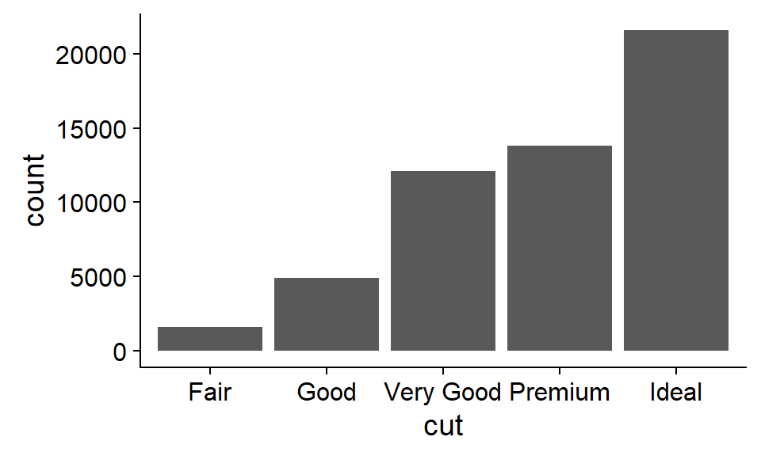

```r
ggplot(data = diamonds) +
  geom_bar(mapping = aes(x = cut))
```

On the x-axis, the chart displays `cut`, a variable from `diamonds`. On the y-axis, it displays count, but count is not a variable in `diamonds`! Where does count come from? Many graphs, like scatterplots, plot the raw values of your dataset. Other graphs, like bar charts, calculate new values to plot:

- bar charts, histograms, and frequency polygons bin your data and then plot bin counts, the number of points that fall in each bin.
- smoothers fit a model to your data and then plot predictions from the model.
- boxplots compute a robust summary of the distribution and then display a specially formatted box.

ggplot2 provides over 20 stats for you to use. Each stat is a function, so you can get help in usual way, e.g. `?stat_bin`. To see a complete list of stats, try the ggplot2 cheatsheet.

## Position adjustments

There's one more piece of magic associated with bar charts. You can colour a bar chart using either the `colour` aesthetic, or more usefully, `fill`:

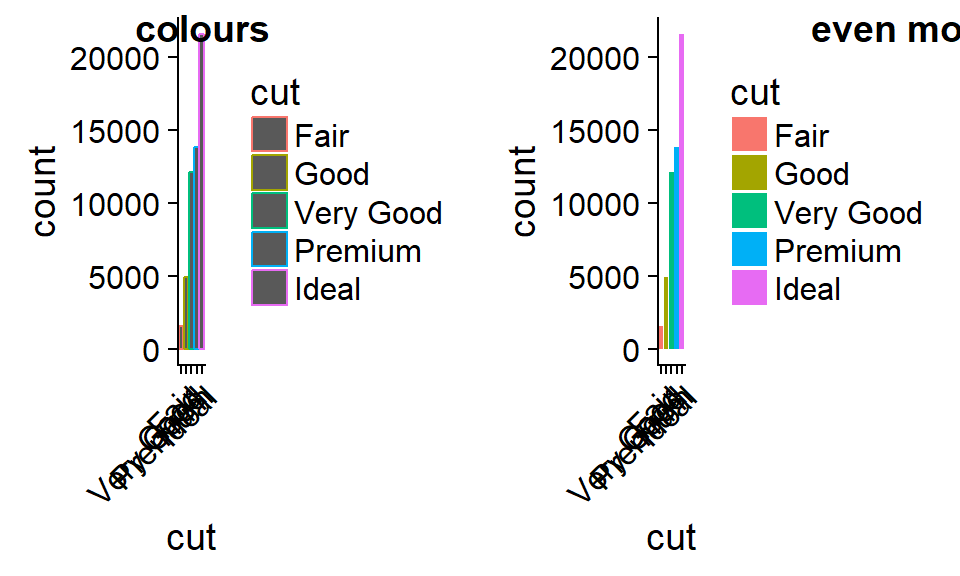

```r
colours <- ggplot(data = diamonds) +
  geom_bar(mapping = aes(x = cut, colour = cut))+
  theme(axis.text.x = element_text(angle = 45, hjust = 1))

more_colours <- ggplot(data = diamonds) +
  geom_bar(mapping = aes(x = cut, fill = cut)) +
  theme(axis.text.x = element_text(angle = 45, hjust = 1))


panel3 <- cowplot::plot_grid(colours, more_colours, labels = c("colours",
"even more colours"), hjust = -1)

panel3
```

Note what happens if you map the fill aesthetic to another variable, like `clarity`: the bars are automatically stacked. Each colored rectangle represents a combination of `cut` and `clarity`.

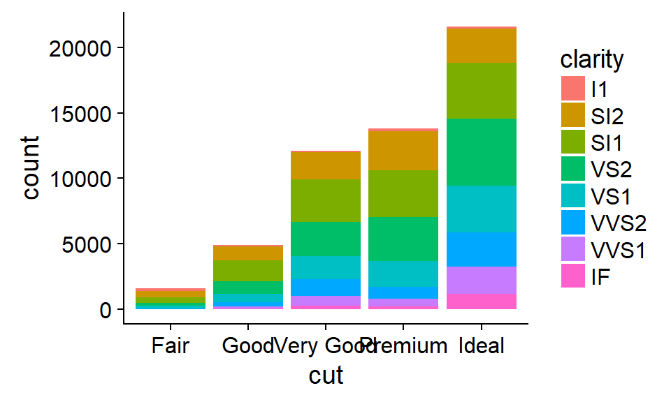

```r
ggplot(data = diamonds) +
  geom_bar(mapping = aes(x = cut, fill = clarity))
```

The stacking is performed automatically by the **position adjustment** specified by the `position` argument. If you don't want a stacked bar chart, you can use one of three other options: `"identity"`, `"dodge"` or `"fill"`.

- `position = "identity"` will place each object exactly where it falls in the context of the graph. This is not very useful for bars, because it overlaps them. To see that overlapping we either need to make the bars slightly transparent by setting `alpha` to a small value, or completely transparent by setting `fill = NA`.

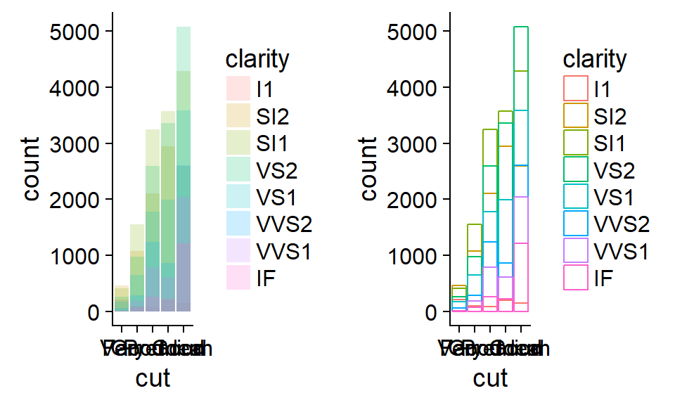

```r
  stacked <- ggplot(data = diamonds, mapping = aes(x = cut, fill = clarity)) +
      geom_bar(alpha = 1/5, position = "identity")

  stacked_not_filled <- ggplot(data = diamonds, mapping = aes(x = cut, colour = clarity)) +
      geom_bar(fill = NA, position = "identity")

cowplot::plot_grid(stacked, stacked_not_filled)
```

```
The identity position adjustment is more useful for 2d geoms, like points,
where it is the default.
```

- `position = "fill"` works like stacking, but makes each set of stacked bars the same height. This makes it easier to compare proportions across groups.

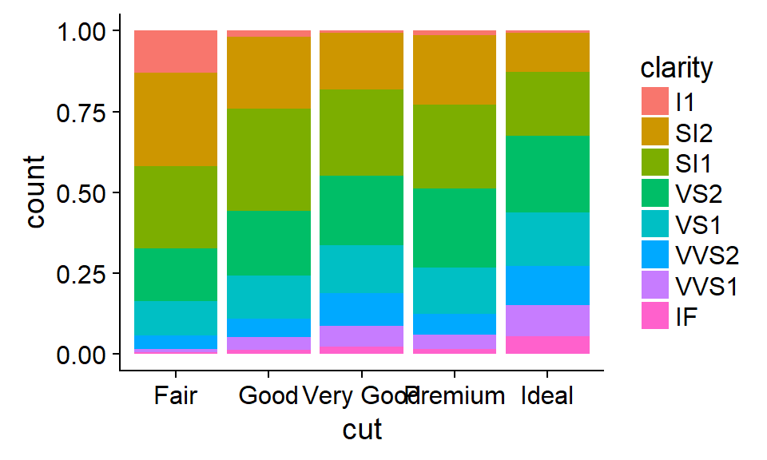

```r
    ggplot(data = diamonds) +
      geom_bar(mapping = aes(x = cut, fill = clarity), position = "fill")
```

- `position = "dodge"` places overlapping objects directly *beside* one another. This makes it easier to compare individual values.

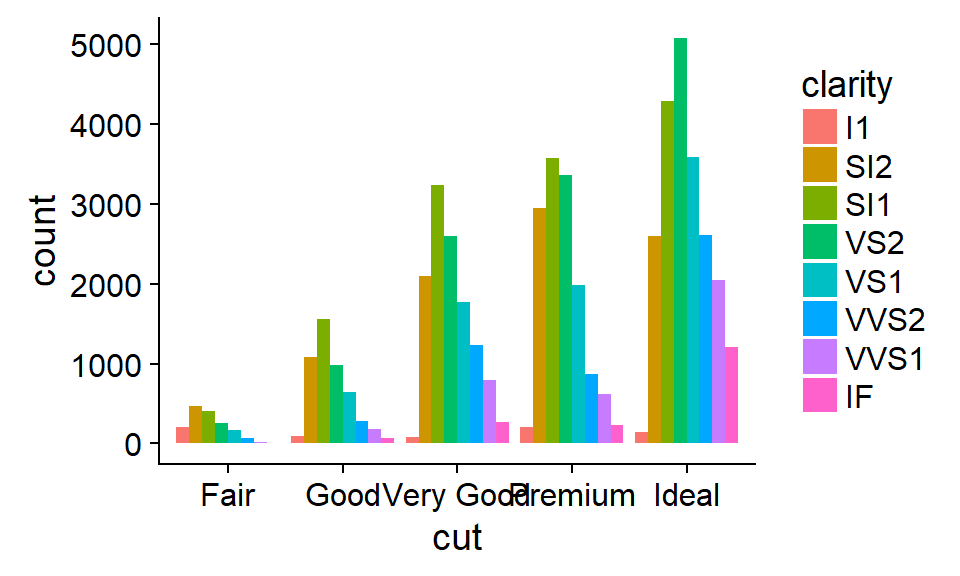

```r
    ggplot(data = diamonds) +
      geom_bar(mapping = aes(x = cut, fill = clarity), position = "dodge")
```

There's one other type of adjustment that's not useful for bar charts, but it can be very useful for scatterplots. Recall our first scatterplot. Did you notice that the plot displays only 126 points, even though there are 234 observations in the dataset?

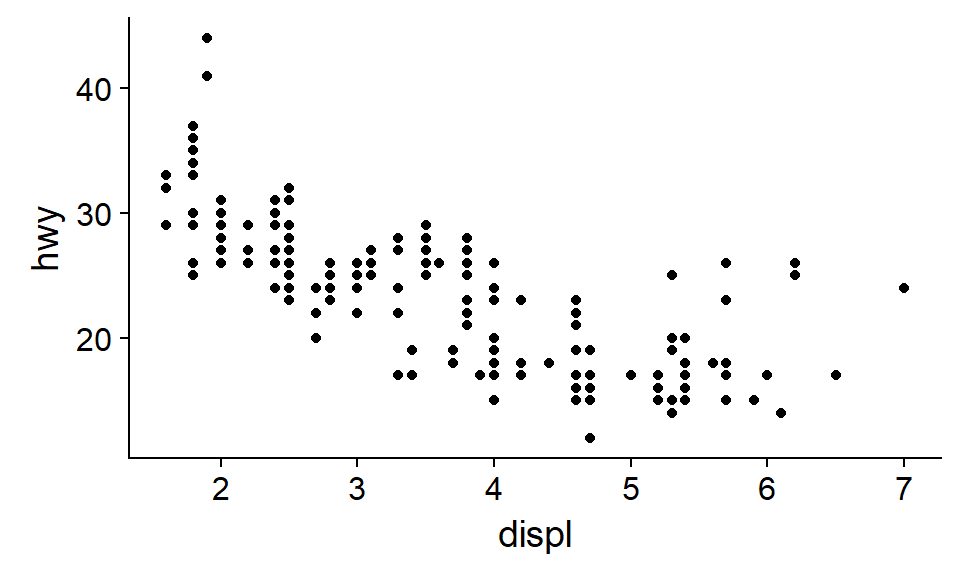

The values of `hwy` and `displ` are rounded so the points appear on a grid and many points overlap each other. This problem is known as **overplotting**. This arrangement makes it hard to see where the mass of the data is. Are the data points spread equally throughout the graph, or is there one special combination of `hwy` and `displ` that contains 109 values?

You can avoid this gridding by setting the position adjustment to "jitter". `position = "jitter"` adds a small amount of random noise to each point. This spreads the points out because no two points are likely to receive the same amount of random noise.

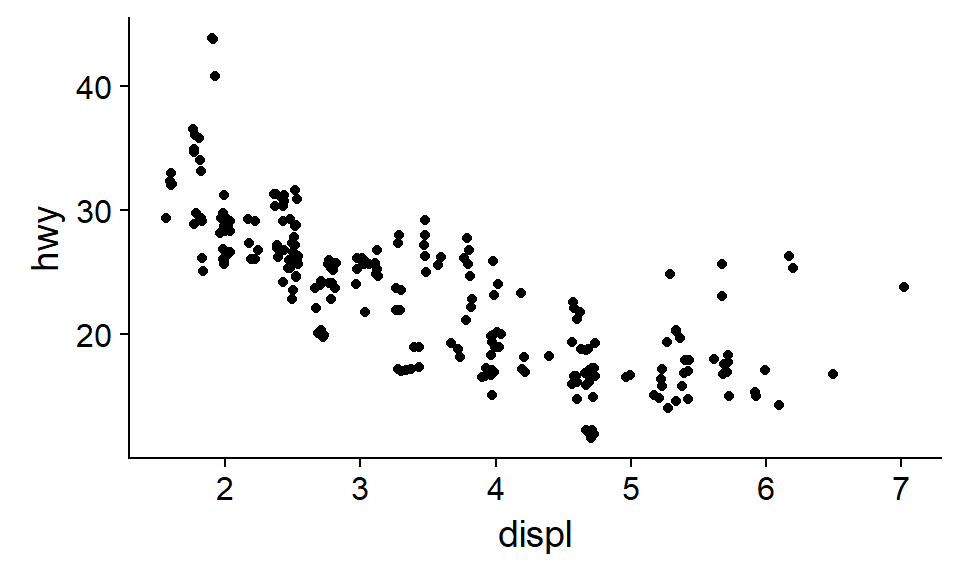

```r
ggplot(data = mpg) +
  geom_point(mapping = aes(x = displ, y = hwy), position = "jitter")
```

Adding randomness seems like a strange way to improve your plot, but while it makes your graph less accurate at small scales, it makes your graph *more* revealing at large scales. Because this is such a useful operation, ggplot2 comes with a shorthand for `geom_point(position = "jitter")`: `geom_jitter()`.

To learn more about a position adjustment, look up the help page associated with each adjustment: `?position_dodge`, `?position_fill`, `?position_identity`, `?position_jitter`, and `?position_stack`.

## The layered grammar of graphics

- Learned much more than how to make scatterplots.
- Bar charts, and boxplots.
- You learned a foundation that you can use to make *any* type of plot with ggplot2.
- To see this, let's add position adjustments, stats, coordinate systems, and faceting to our code template:

```
ggplot(data = <DATA>) +
  <GEOM_FUNCTION>(
     mapping = aes(<MAPPINGS>),
     stat = <STAT>,
     position = <POSITION>
  ) +
  <COORDINATE_FUNCTION> +
  <FACET_FUNCTION>
```

## More ggplot2

We will learn more during the course during other lessons